# Análisis de regresión lineal — Cohorte ERC

Factores asociados a la tasa de declive de la TFG

Pieralessandro Lasalvia

2026-11-24

```r
library(tidyverse)
library(here)
library(gtsummary)
library(car)

base <- readRDS(here("data", "processed", "base_analitica_v1.0.rds"))

# Estadio como factor nominal con G2 como referencia (ver 04_regresion_logistica.Rmd)
base <- base %>%
  mutate(estadio_basal = factor(estadio_basal, ordered = FALSE))

base_lineal <- base %>%
  filter(!is.na(tasa_declive_tfg),
         !is.na(estadio_basal),
         !is.na(log_proteinuria_basal))

cat("N analítico:", nrow(base_lineal), "\n")
```

```
## N analítico: 246
```

```r
cat("Tasa de declive (mediana):",
    round(median(base_lineal$tasa_declive_tfg, na.rm=TRUE), 1),
    "mL/min/año\n")
```

```
## Tasa de declive (mediana): -4.5 mL/min/año
```

# 1 Plan de análisis

Este documento implementa el análisis 2 del plan: regresión lineal para la tasa de declive de la TFG (mL/min/año), con el estadio basal como exposición principal (referencia G2) y ajuste por edad, sexo, diabetes, hipertensión arterial, log-proteinuria, hemoglobina, presión arterial sistólica (PAS) y uso de IECA o ARA2.

La tasa de declive se calcula con la TFG del mes 24, así que solo existe para quien completó el seguimiento. Se excluyen 54 participantes (18%) sin TFG al mes 24; las demás variables del modelo no tienen faltantes. La tabla siguiente compara el estadio basal de incluidos y excluidos.

```r
# ¿Difieren los excluidos de los incluidos en el estadio basal?
base %>%
  mutate(incluido = if_else(is.na(tasa_declive_tfg),
                            "Excluido (sin TFG mes 24)", "Incluido")) %>%
  count(incluido, estadio_basal) %>%
  group_by(incluido) %>%
  mutate(pct = round(n / sum(n) * 100, 1)) %>%
  pivot_wider(names_from = incluido, values_from = c(n, pct)) %>%
  knitr::kable(caption = "Estadio basal de los participantes incluidos y excluidos")
```

Estadio basal de los participantes incluidos y excluidos

| estadio_basal | n_Excluido (sin TFG mes 24) | n_Incluido | pct_Excluido (sin TFG mes 24) | pct_Incluido |
| --- | --- | --- | --- | --- |
| G2 | 13 | 56 | 24.1 | 22.8 |
| G3a | 13 | 80 | 24.1 | 32.5 |
| G3b | 21 | 64 | 38.9 | 26.0 |
| G4 | 7 | 46 | 13.0 | 18.7 |

```r
p_exclusion <- chisq.test(table(is.na(base$tasa_declive_tfg),
                                base$estadio_basal))$p.value
```

Entre los excluidos hay proporcionalmente más participantes en G3b y menos en G3a y G4 que entre los incluidos, aunque la diferencia en la distribución por estadio no es estadísticamente significativa (chi-cuadrado, p = 0.22). El análisis de casos completos supone que los faltantes son completamente al azar (MCAR); con este patrón el supuesto es plausible pero no verificable, y se registra como limitación.

# 2 Distribución del desenlace

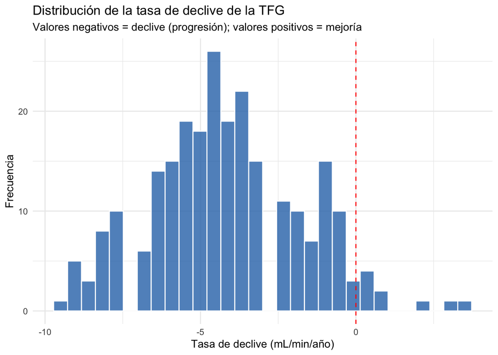

```r
ggplot(base_lineal, aes(x = tasa_declive_tfg)) +
  geom_histogram(bins = 30, fill = "#2E75B6", color = "white", alpha = 0.8) +
  geom_vline(xintercept = 0, linetype = "dashed", color = "red") +
  labs(title = "Distribución de la tasa de declive de la TFG",
       subtitle = "Valores negativos = declive (progresión); valores positivos = mejoría",
       x = "Tasa de declive (mL/min/año)",
       y = "Frecuencia") +
  theme_minimal()
```

```r
pct_declive <- mean(base_lineal$tasa_declive_tfg < 0) * 100
q_declive   <- quantile(base_lineal$tasa_declive_tfg, c(0.25, 0.5, 0.75))
```

# 3 Modelo crudo

```r
# Modelo sin ajuste: estadio como única variable
modelo_crudo <- lm(tasa_declive_tfg ~ estadio_basal, data = base_lineal)

tbl_regression(modelo_crudo,
               label = list(estadio_basal ~ "Estadio de ERC (ref: G2)")) %>%
  bold_p(t = 0.05) %>%
  bold_labels() %>%
  modify_caption("**Tabla. Coeficientes crudos para tasa de declive de TFG**")
```

**Tabla. Coeficientes crudos para tasa de declive de TFG**

| **Characteristic** | **Beta** | **95% CI** | **p-value** |
| --- | --- | --- | --- |
| Estadio de ERC (ref: G2) |  |  |  |
| G2 | — | — |  |
| G3a | 0.04 | -0.76, 0.83 | >0.9 |
| G3b | -0.11 | -0.95, 0.73 | 0.8 |
| G4 | -1.9 | -2.8, -0.96 | <0.001 |

Abbreviation: CI = Confidence Interval

```r
coef_crudo <- broom::tidy(modelo_crudo, conf.int = TRUE)
b_crudo <- function(term) coef_crudo$estimate[coef_crudo$term == term]
media_g2 <- b_crudo("(Intercept)")
```

**Interpretación de los coeficientes crudos.** El intercepto es el declive medio de G2: -3.8 mL/min/año. G4 declina 1.9 mL/min/año más rápido que G2, mientras que G3a y G3b no difieren (diferencias de 0.04 y -0.11 mL/min/año). La asociación no aumenta de forma gradual con el estadio: se concentra en G4. El estadio solo explica el 9% de la variabilidad del declive.

# 4 Modelo ajustado

```r
modelo_lineal <- lm(
  tasa_declive_tfg ~ estadio_basal + edad + sexo +
    diabetes + hipertension +
    log_proteinuria_basal + hemoglobina_g_dl_basal +
    pas_mmhg_basal + ieca_o_ara2,
  data = base_lineal
)

tbl_regression(modelo_lineal,
               label = list(
                 estadio_basal          ~ "Estadio de ERC (ref: G2)",
                 edad                   ~ "Edad (por año)",
                 sexo                   ~ "Sexo (ref: femenino)",
                 diabetes               ~ "Diabetes mellitus",
                 hipertension           ~ "Hipertensión arterial",
                 log_proteinuria_basal  ~ "Log-proteinuria (por unidad)",
                 hemoglobina_g_dl_basal ~ "Hemoglobina (por g/dL)",
                 pas_mmhg_basal         ~ "PAS (por mmHg)",
                 ieca_o_ara2            ~ "IECA o ARA2"
               )) %>%
  bold_p(t = 0.05) %>%
  bold_labels() %>%
  modify_caption("**Tabla. Coeficientes ajustados para tasa de declive de TFG**")
```

**Tabla. Coeficientes ajustados para tasa de declive de TFG**

| **Characteristic** | **Beta** | **95% CI** | **p-value** |
| --- | --- | --- | --- |
| Estadio de ERC (ref: G2) |  |  |  |
| G2 | — | — |  |
| G3a | 0.05 | -0.74, 0.85 | >0.9 |
| G3b | -0.05 | -0.87, 0.78 | >0.9 |
| G4 | -2.0 | -2.9, -1.1 | <0.001 |
| Edad (por año) | 0.00 | -0.02, 0.03 | 0.8 |
| Sexo (ref: femenino) |  |  |  |
| Femenino | — | — |  |
| Masculino | -0.01 | -0.59, 0.57 | >0.9 |
| Diabetes mellitus |  |  |  |
| FALSE | — | — |  |
| TRUE | -0.70 | -1.3, -0.10 | 0.022 |
| Hipertensión arterial |  |  |  |
| FALSE | — | — |  |
| TRUE | -0.08 | -0.95, 0.79 | 0.9 |
| Log-proteinuria (por unidad) | -0.10 | -0.37, 0.17 | 0.5 |
| Hemoglobina (por g/dL) | -0.15 | -0.31, 0.02 | 0.085 |
| PAS (por mmHg) | 0.00 | -0.01, 0.02 | 0.6 |
| IECA o ARA2 |  |  |  |
| FALSE | — | — |  |
| TRUE | -0.86 | -1.5, -0.26 | 0.005 |

Abbreviation: CI = Confidence Interval

```r
# Valores para la interpretación
coef_lin <- broom::tidy(modelo_lineal, conf.int = TRUE)
b <- function(term) coef_lin$estimate[coef_lin$term == term]
r2 <- summary(modelo_lineal)$r.squared
```

**Interpretación de los coeficientes.** Un coeficiente negativo indica un declive más rápido que la categoría de referencia. G4 es el único estadio que difiere de G2: pierde 2.0 mL/min/año más, frente a 1.9 en el modelo crudo, así que el ajuste casi no cambia la asociación. G3a y G3b declinan al mismo ritmo que G2 (diferencias de 0.05 y -0.05 mL/min/año). La diabetes se asocia con un declive 0.7 mL/min/año más rápido, en la dirección esperada. El uso de IECA o ARA2 también se asocia con un declive más rápido (-0.9 mL/min/año), lo contrario del efecto nefroprotector conocido. En un estudio observacional esto sugiere confusión por indicación: los IECA y ARA2 se prescriben a pacientes con más proteinuria o enfermedad más activa. Edad, sexo, hipertensión, log-proteinuria, hemoglobina y PAS no muestran asociación. El modelo explica el 15.1% de la variabilidad del declive.

# 5 Verificación de supuestos

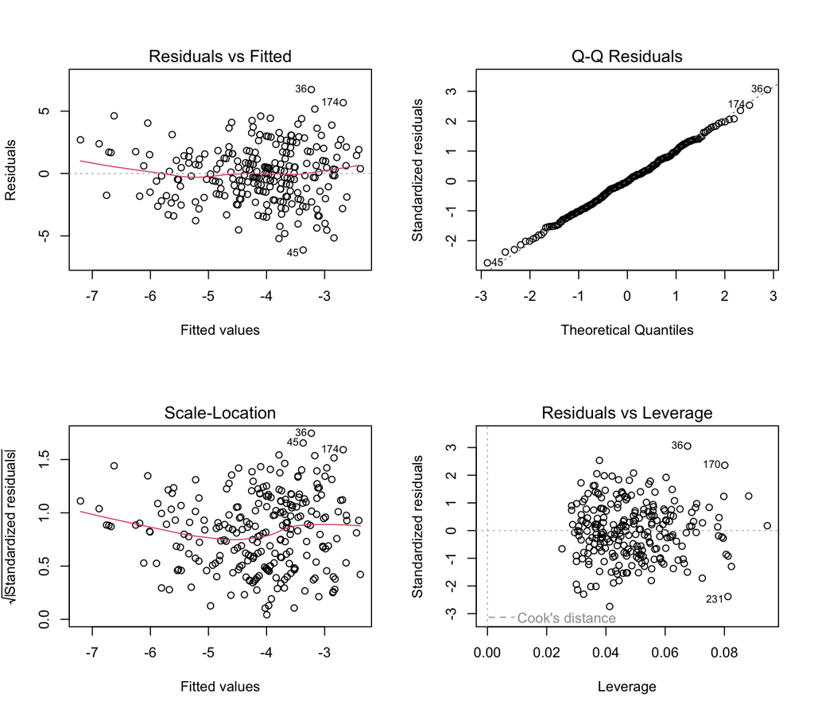

```r
# Cuatro gráficos diagnósticos
par(mfrow = c(2, 2))
plot(modelo_lineal)
```

```r
par(mfrow = c(1, 1))
```

```r
cat("VIF del modelo lineal:\n")
```

```
## VIF del modelo lineal:
```

```r
print(round(vif(modelo_lineal), 2))
```

```
##                        GVIF Df GVIF^(1/(2*Df))
## estadio_basal          1.12  3            1.02
## edad                   1.03  1            1.01
## sexo                   1.01  1            1.01
## diabetes               1.06  1            1.03
## hipertension           1.07  1            1.03
## log_proteinuria_basal  1.03  1            1.02
## hemoglobina_g_dl_basal 1.10  1            1.05
## pas_mmhg_basal         1.02  1            1.01
## ieca_o_ara2            1.04  1            1.02
```

```r
# Observaciones con mayor influencia (distancia de Cook)
cook <- cooks.distance(modelo_lineal)
cat("Distancia de Cook máxima:", round(max(cook), 3), "\n")
```

```
## Distancia de Cook máxima: 0.056
```

```r
cat("Observaciones con Cook > 4/n:", sum(cook > 4 / nobs(modelo_lineal)), "\n")
```

```
## Observaciones con Cook > 4/n: 8
```

**Interpretación de los gráficos diagnósticos.** En *Residuals vs Fitted* los residuos se reparten alrededor de cero; la línea de suavizado se curva un poco en los valores ajustados más bajos, donde hay pocos puntos, sin un patrón en U ni en embudo. El *Q-Q plot* sigue la diagonal en todo su recorrido, incluidas las colas. En *Scale-Location* la línea es casi horizontal, así que no hay evidencia visual de heterocedasticidad. En *Residuals vs Leverage* las líneas de distancia de Cook de 0.5 ni siquiera entran en el gráfico: la distancia máxima es 0.056. Ningún caso individual determina los coeficientes. Los VIF son bajos, sin colinealidad relevante. La semana 15 complementa esta inspección con pruebas formales (Breusch-Pagan y Shapiro-Wilk).

# 6 Información de sesión